# Final Project

Data Science for Biologists, Spring 2021

Lalita Martin

## Introduction

The datasets I have chosen are the [National Parks Biodiversity](https://www.kaggle.com/nationalparkservice/park-biodiversity) datasets from Kaggle. They are about National Parks and the species of various organisms found in these parks. I chose these datasets because I want to be a biologist on some level and I enjoy looking at biodiversity all over the world. These datasets show species diversity in various national parks, which I also like, as I have a great interest in working for the parks dept. one day.

```r
#set file path
parks_file <- file.path("martin_parks.csv")
species_file <- file.path("martin_species.csv")
#read in datasets
parks <-read_csv(parks_file)
species <- read_csv(species_file)
#glimpse parks and species datasets
glimpse(parks)
```

```
## Rows: 56
## Columns: 6
## $ `Park Code` <chr> "ACAD", "ARCH", "BADL", "BIBE", "BISC", "BLCA", "BRCA", "…
## $ `Park Name` <chr> "Acadia National Park", "Arches National Park", "Badlands…
## $ State       <chr> "ME", "UT", "SD", "TX", "FL", "CO", "UT", "UT", "UT", "NM…
## $ Acres       <dbl> 47390, 76519, 242756, 801163, 172924, 32950, 35835, 33759…
## $ Latitude    <dbl> 44.35, 38.68, 43.75, 29.25, 25.65, 38.57, 37.57, 38.20, 3…
## $ Longitude   <dbl> -68.21, -109.57, -102.50, -103.25, -80.08, -107.72, -112.…
```

```r
glimpse(species)
```

```
## Rows: 119,248
## Columns: 14
## $ `Species ID`          <chr> "ACAD-1000", "ACAD-1001", "ACAD-1002", "ACAD-10…
## $ `Park Name`           <chr> "Acadia National Park", "Acadia National Park",…
## $ Category              <chr> "Mammal", "Mammal", "Mammal", "Mammal", "Mammal…
## $ Order                 <chr> "Artiodactyla", "Artiodactyla", "Carnivora", "C…
## $ Family                <chr> "Cervidae", "Cervidae", "Canidae", "Canidae", "…
## $ `Scientific Name`     <chr> "Alces alces", "Odocoileus virginianus", "Canis…
## $ `Common Names`        <chr> "Moose", "Northern White-Tailed Deer, Virginia …
## $ `Record Status`       <chr> "Approved", "Approved", "Approved", "Approved",…
## $ Occurrence            <chr> "Present", "Present", "Present", "Not Confirmed…
## $ Nativeness            <chr> "Native", "Native", "Not Native", "Native", "Un…
## $ Abundance             <chr> "Rare", "Abundant", "Common", NA, "Common", NA,…
## $ Seasonality           <chr> "Resident", NA, NA, NA, "Breeder", NA, "Vagrant…
## $ `Conservation Status` <chr> NA, NA, "Species of Concern", "Endangered", NA,…
## $ X14                   <lgl> NA, NA, NA, NA, NA, NA, NA, NA, NA, NA, NA, NA,…
```

## Question 1

### Methods

```r
parks %>%
  #let's work with only the parks that are solely in one state
  filter(str_detect(State, ",", negate=TRUE)) -> parks_clean # removes rows with , in State column

#Lets take some parks to compare
parks_clean %>%
  filter(Acres > 1000000) %>%
  arrange(-Acres) -> big_parks
big_parks
```

```
## # A tibble: 10 x 6
##    `Park Code` `Park Name`                       State  Acres Latitude Longitude
##    <chr>       <chr>                             <chr>  <dbl>    <dbl>     <dbl>
##  1 WRST        Wrangell - St Elias National Par… AK    8.32e6     61      -142
##  2 GAAR        Gates Of The Arctic National Par… AK    7.52e6     67.8    -153.
##  3 KATM        Katmai National Park and Preserve AK    3.67e6     58.5    -155
##  4 DENA        Denali National Park and Preserve AK    3.37e6     63.3    -150.
##  5 GLBA        Glacier Bay National Park and Pr… AK    3.22e6     58.5    -137
##  6 LACL        Lake Clark National Park and Pre… AK    2.62e6     61.0    -153.
##  7 KOVA        Kobuk Valley National Park        AK    1.75e6     67.6    -159.
##  8 EVER        Everglades National Park          FL    1.51e6     25.3     -80.9
##  9 GRCA        Grand Canyon National Park        AZ    1.22e6     36.1    -112.
## 10 GLAC        Glacier National Park             MT    1.01e6     48.8    -114
```

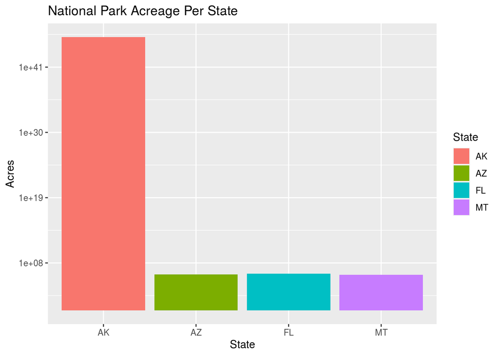

```r
ggplot(big_parks)+
  aes(x = State, y = Acres, fill = State)+
  scale_y_log10()+
  geom_col()+
  labs(title = "National Park Acreage Per State")+
  theme_grey()
```

## Question 2

#### Which parks have the most fungi species growing in them?

### Methods

```r
species %>%
  rename(park_name = `Park Name`) %>%
  filter(Category == "Fungi") %>%
  filter(Occurrence == "Present") %>%
  count(park_name) %>%
  filter(n > 200) %>%
  arrange(-n) -> fun_guy
fun_guy
```

```
## # A tibble: 6 x 2
##   park_name                               n
##   <chr>                               <int>
## 1 Shenandoah National Park              712
## 2 Great Smoky Mountains National Park   606
## 3 North Cascades National Park          539
## 4 Rocky Mountain National Park          298
## 5 Congaree National Park                277
## 6 Glacier National Park                 276
```

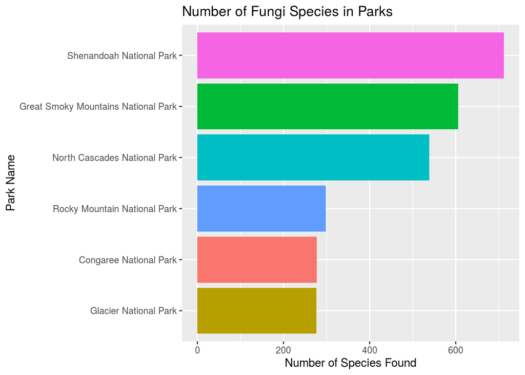

```r
ggplot(fun_guy)+
  aes(y = reorder(park_name, n), x = n, fill = park_name)+
  geom_col()+
  theme_grey()+
  theme(legend.position = "none")+
  labs(title = "Number of Fungi Species in Parks",
       x = "Number of Species Found",
       y = "Park Name")
```

### Answer

**Shenandoah National Park** has the most species of fungi, followed by Great Smoky Mountains, North Cascades National Park, and three others all with more than 200 species found!

## Question 3

#### Which parks have the greatest amounts of algae species?

### Methods

```r
species %>%
  rename(park_name = `Park Name`) %>%
  filter(Category == "Algae") %>%
  filter(Occurrence == "Present") %>%
  count(park_name) %>%
  filter(n > 50) %>%
  arrange(-n) -> gee_al
gee_al
```

```
## # A tibble: 4 x 2
##   park_name                                  n
##   <chr>                                  <int>
## 1 Rocky Mountain National Park             150
## 2 Congaree National Park                    74
## 3 Channel Islands National Park             61
## 4 Glacier Bay National Park and Preserve    57
```

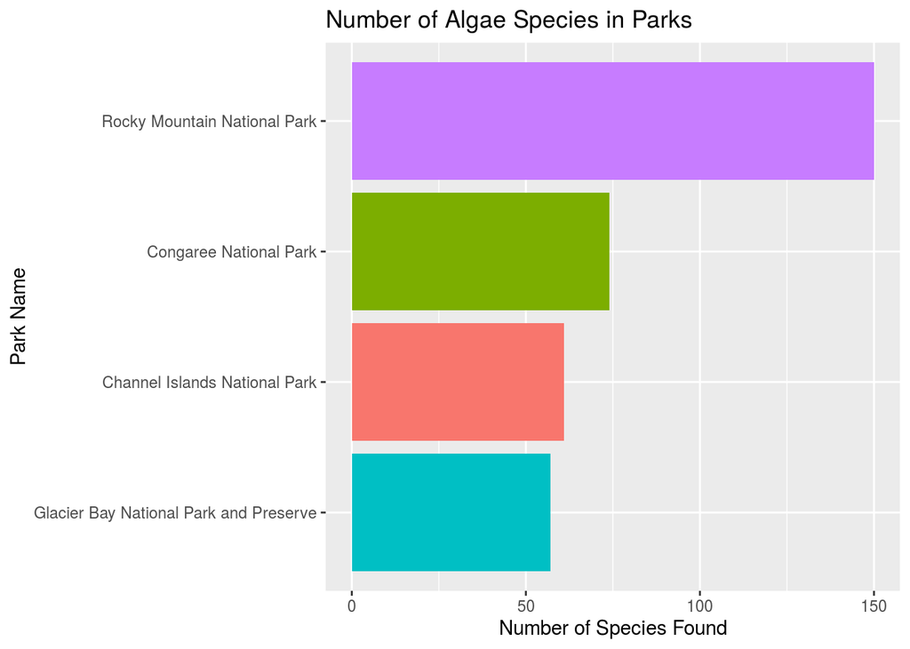

```r
ggplot(gee_al)+
  aes(y = reorder(park_name, n), x = n, fill = park_name)+
  geom_col()+
  theme_grey()+
  theme(legend.position = "none")+
  labs(title = "Number of Algae Species in Parks",
       x = "Number of Species Found",
       y = "Park Name")
```

### Answer

Rocky Mountain National Park had the highest amount of reported algae species of **150!** Followed by Congaree with **74**, Channel Islands at **61** and Glacier Bay at **57.**

## Question 4

#### How many *different* vascular plants are in Death Valley compared to The Great Smoky Mountain National Park?

### Methods

```r
species %>%
  rename(park_name = `Park Name`) %>%
  rename(sci_name = `Scientific Name`) %>%
  rename(common_name = `Common Names`) %>%
  filter(Category == "Vascular Plant") %>%
  filter(park_name == c("Death Valley National Park", "Great Smoky Mountains National Park")) %>%
  filter(Occurrence == "Present") %>%
  count(park_name)-> plants
plants
```

```
## # A tibble: 2 x 2
##   park_name                               n
## * <chr>                               <int>
## 1 Death Valley National Park            491
## 2 Great Smoky Mountains National Park   818
```

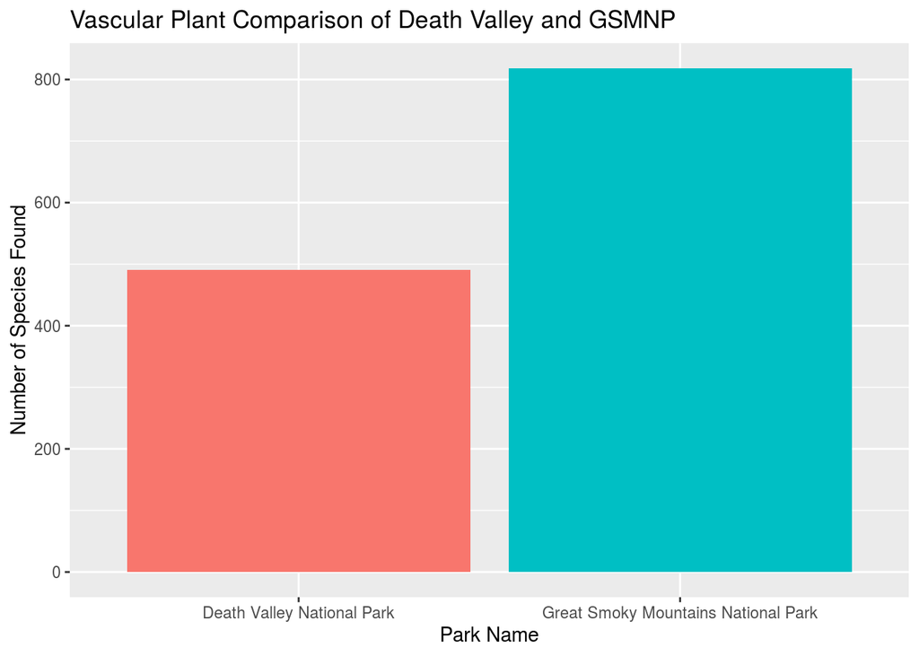

```r
ggplot(plants)+
  aes(x = reorder(park_name, n), y = n, fill = park_name)+
  geom_col()+
  theme_grey()+
  theme(legend.position = "none")+
  labs(title = "Vascular Plant Comparison of Death Valley and GSMNP",
       y = "Number of Species Found",
       x = "Park Name")
```

### Answer

In Death Valley, there are **491** species of vascular plant and in the GSMNP there are **818.**